# Course Kickoff: Why AI Agents Now

Day 2 - Block 1 | May 14, 2027 | Building AI Agents (Advanced)

[figure not shown]

[figure not shown]

[figure not shown]

## Finn-Ole Höner

**PhD Candidate in Quantitative Marketing (ESE)**

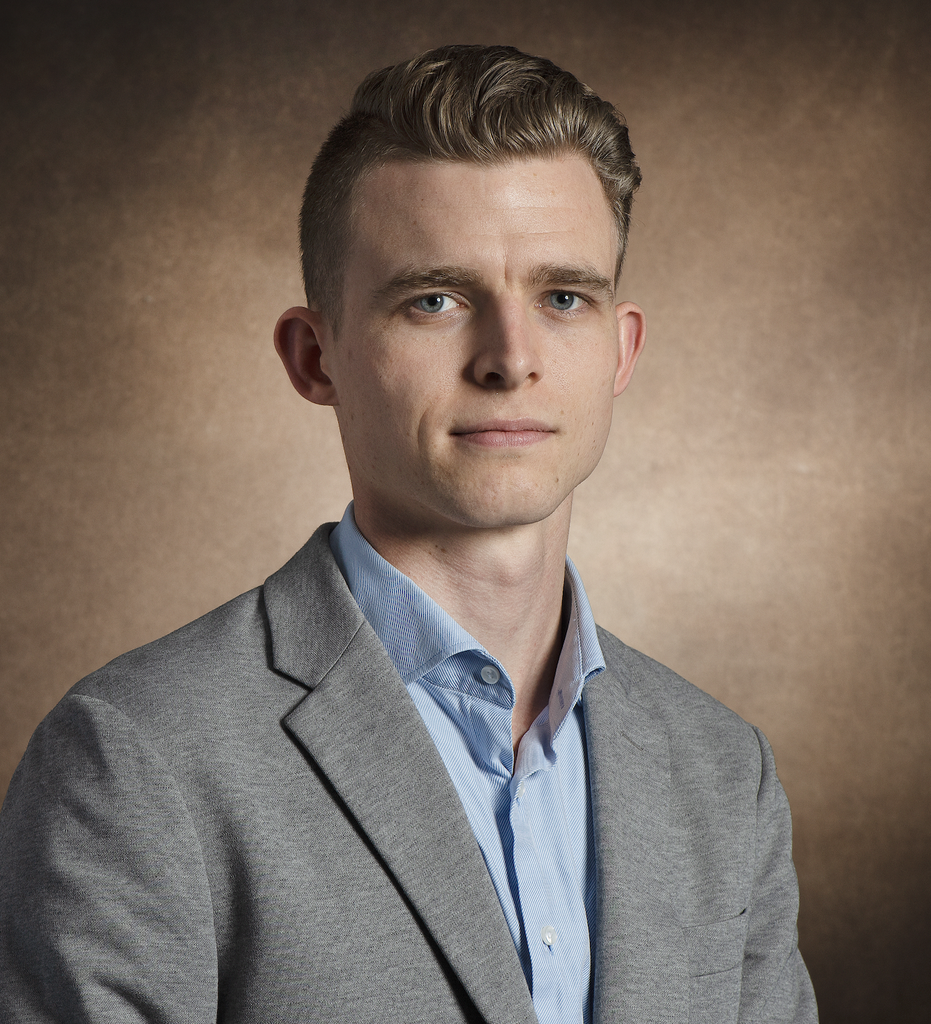

LLMs for Innovation:

- Ideation with AI Agent teams (Dr. van Crombrugge, Dr. Wichmann, Prof. Stremersch)
- Refining and validating ideas for marketing texts (Prof. Donkers, Prof. Fok)
- Synthetic respondents for sensitive topics (Prof. de Jong, Prof. Pieters)

**Background:**  
BDS, Deutsche Bundesbank, Lidl, University of Tübingen

# Why do we care?

A [*Nature*](https://www.nature.com/articles/d41586-023-02980-0) survey of scientists found that …

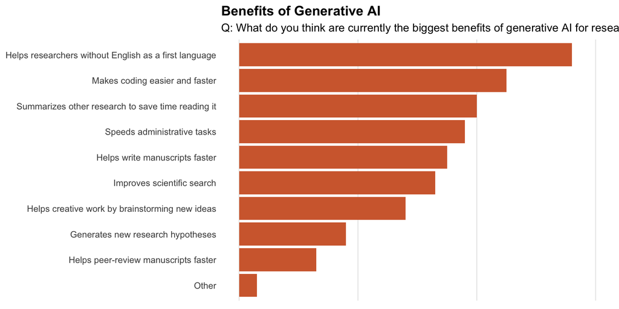

## Q1 Programming AI use (n=25)

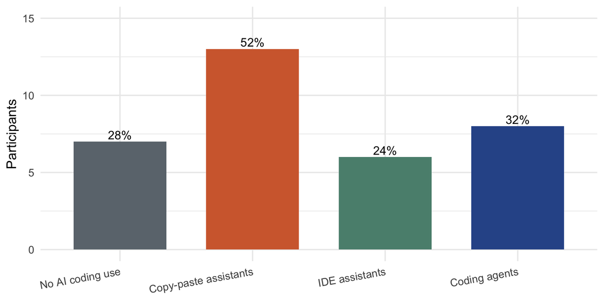

- Course link: onboarding, LLM basics, verification loop

## Q2 AI use in research

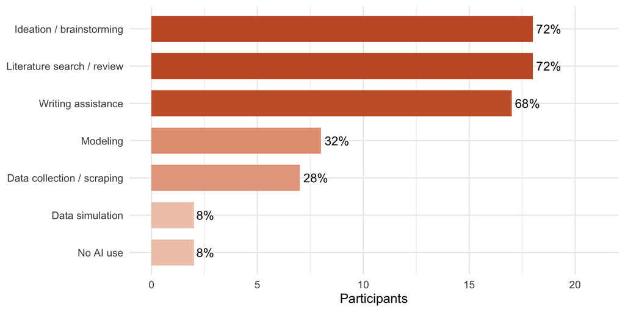

- Course link: ideation, literature review, writing, analysis, data collection

## Q3 Top priorities (free text)

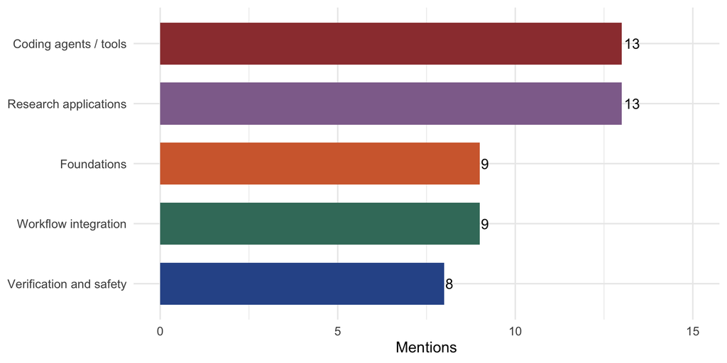

- Course link: tools, tool building, memory, rigorous analysis, workflows

## Q4 Laptop mix

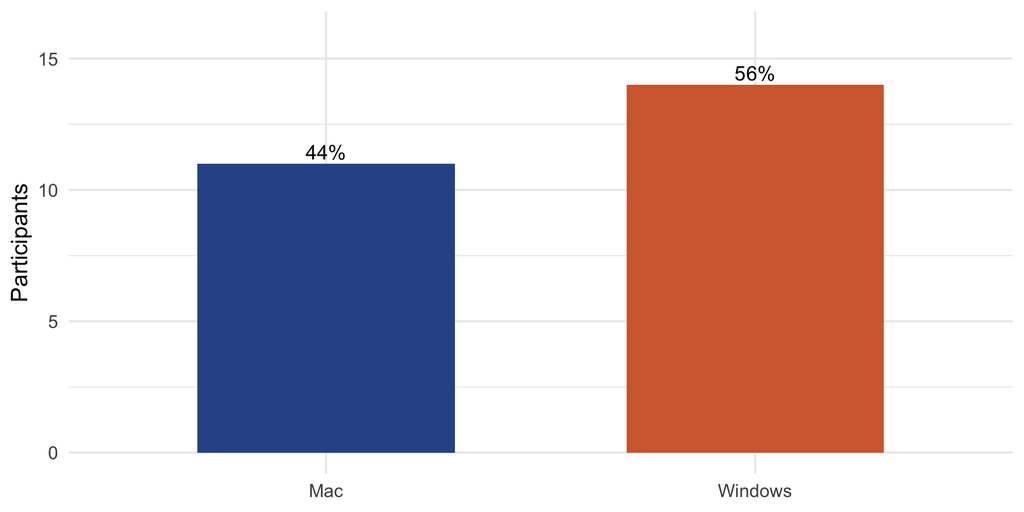

- Course link: setup support and in-class troubleshooting

## Q5 Paid subscriptions

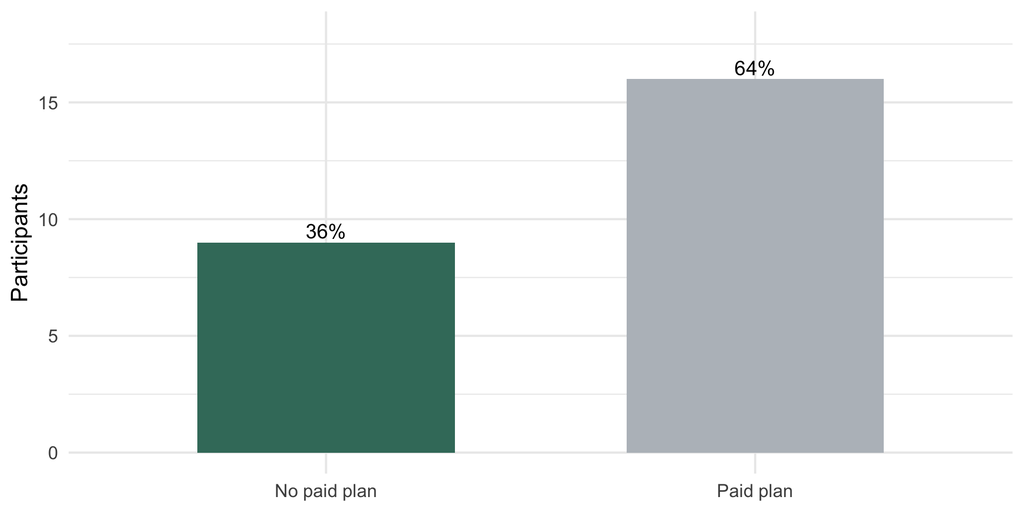

- Course link: local and open workflows; no paid-only requirements

## Q6 Direct API experience

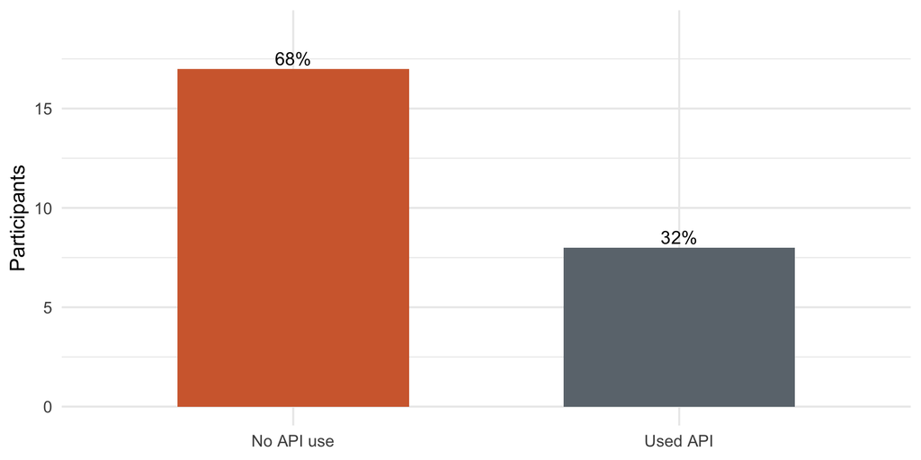

- Course link: tool calls first, MCP builder second

## Q7 Language profile

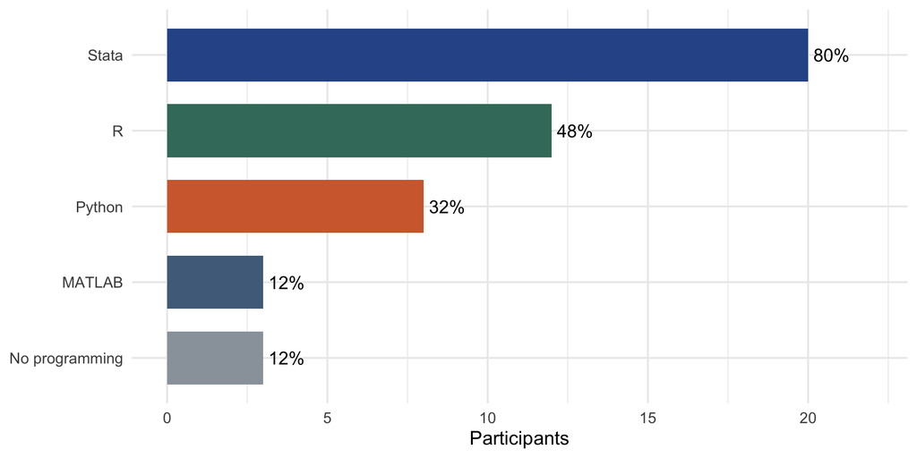

- Course link: language-flexible workflows, tool-first demos, verification habits

## Q8 Comments, wishes, questions

- Requests: Stata fit, multi-agent practice, security guidance
- Concern: restricted data leakage when using agents
- Course link: privacy-by-design and permission-restricted modes

## (A necessary) Disclaimer

1. Massive amounts of work on this topic are happening right now
2. Many, many (legal, ethical, environmental, social) questions are open
3. AI is fuzzy + a lot of hype

Wide overview -> Experiment on your own!

# Meet Jan: AI tutor for this course!

Github: `finnoh/ti-student-agent-pack`

```
You: I want to work on E03.

Jan: +------------------------------------------+
     | Exercise E03 - Context + Retrieval      |
     | Objective: Compare baseline vs retrieval|
     | Deliverable: A/B note + cited chunk     |
     +------------------------------------------+

     First step: run the baseline (no retrieval)
     and paste the output so we can compare fairly.
```

**Installation:**

```bash
curl -sL https://raw.githubusercontent.com/finnoh/ti-student-agent-pack/main/install.sh | bash
```

## How to Use Jan

1. Open a terminal
2. `cd path/to/student-agent-pack`
3. `opencode`

## Hands-on: Explore Jan

**Task:** Set up Jan and have a look around

1. Install Jan: `curl -sL ... | bash` (or use the course pack zip)
2. Open `student-agent-pack/`
3. Explore the directory structure and files (what do you see?)
4. Chat with Jan (what does Jan do?)
5. Can you customize Jan to your needs?

## References

TI Workshop | D2 B1